# Traffic_Sign_Classifier

```python
!git clone https://bitbucket.org/jadslim/german-traffic-signs
```

```
Cloning into 'german-traffic-signs'...
remote: Counting objects: 6, done.
remote: Compressing objects: 100% (6/6), done.
remote: Total 6 (delta 0), reused 0 (delta 0)
Unpacking objects: 100% (6/6), done.
```

```python
!ls german-traffic-signs
!pwd
```

```
signnames.csv  test.p  train.p	valid.p
/content
```

```python
# Load pickled data
import pickle
import pandas as pd
import matplotlib.pyplot as plt; plt.rcdefaults()
import numpy as np
import matplotlib.pyplot as plt
import cv2
from imgaug import augmenters as iaa

training_file = 'german-traffic-signs/train.p'
validation_file='german-traffic-signs/valid.p'
testing_file = 'german-traffic-signs/test.p'
class_labels = pd.read_csv('german-traffic-signs/signnames.csv')

with open(training_file, mode='rb') as f:
    train = pickle.load(f)
with open(validation_file, mode='rb') as f:
    valid = pickle.load(f)
with open(testing_file, mode='rb') as f:
    test = pickle.load(f)

X_train, y_train = train['features'], train['labels']
X_valid, y_valid = valid['features'], valid['labels']
X_test, y_test = test['features'], test['labels']

print(X_train.shape)
print(y_train.shape)
print(X_valid.shape[0])
print(X_test.shape[0])
```

```
(34799, 32, 32, 3)
(34799,)
4410
12630
```

```python
from sklearn.model_selection import train_test_split
# X_train, X_valid, y_train, y_valid = train_test_split(X_train, y_train, test_size = 0.2, random_state=1)
# X_train, X_valid, y_train, y_valid = train_test_split(X_train, y_train, test_size=0.2, shuffle=False, random_state=0)
print("Updated Image Shape: {}".format(X_train[0].shape))

print(class_labels)
```

```
Updated Image Shape: (32, 32, 3)
    ClassId                                           SignName
0         0                               Speed limit (20km/h)
1         1                               Speed limit (30km/h)
2         2                               Speed limit (50km/h)
3         3                               Speed limit (60km/h)
4         4                               Speed limit (70km/h)
5         5                               Speed limit (80km/h)
6         6                        End of speed limit (80km/h)
7         7                              Speed limit (100km/h)
8         8                              Speed limit (120km/h)
9         9                                         No passing
10       10       No passing for vechiles over 3.5 metric tons
11       11              Right-of-way at the next intersection
12       12                                      Priority road
```

[output cut: 30 more lines]

## Step 1: Dataset Summary & Exploration

The pickled data is a dictionary with 4 key/value pairs:

- `'features'` is a 4D array containing raw pixel data of the traffic sign images, (num examples, width, height, channels).
- `'labels'` is a 1D array containing the label/class id of the traffic sign. The file `signnames.csv` contains id -> name mappings for each id.
- `'sizes'` is a list containing tuples, (width, height) representing the original width and height the image.
- `'coords'` is a list containing tuples, (x1, y1, x2, y2) representing coordinates of a bounding box around the sign in the image. **THESE COORDINATES ASSUME THE ORIGINAL IMAGE. THE PICKLED DATA CONTAINS RESIZED VERSIONS (32 by 32) OF THESE IMAGES**

Complete the basic data summary below. Use python, numpy and/or pandas methods to calculate the data summary rather than hard coding the results. For example, the [pandas shape method](http://pandas.pydata.org/pandas-docs/stable/generated/pandas.DataFrame.shape.html) might be useful for calculating some of the summary results.

### Provide a Basic Summary of the Data Set Using Python, Numpy and/or Pandas

```python
### Replace each question mark with the appropriate value.
### Use python, pandas or numpy methods rather than hard coding the results

# TODO: Number of training examples
n_train = X_train.shape[0]

# TODO: Number of validation examples
n_validation = X_valid.shape[0]

# TODO: Number of testing examples.
n_test = X_test.shape[0]

# TODO: What's the shape of an traffic sign image?
image_shape = X_train[0].shape

# TODO: How many unique classes/labels there are in the dataset.
n_classes = len(class_labels)

print("Number of training examples =", n_train)
print("Number of testing examples =", n_test)
print("Image data shape =", image_shape)
print("Number of classes =", n_classes)
```

```
Number of training examples = 34799
Number of testing examples = 12630
Image data shape = (32, 32, 3)
Number of classes = 43
```

### Include an exploratory visualization of the dataset

Visualize the German Traffic Signs Dataset using the pickled file(s). This is open ended, suggestions include: plotting traffic sign images, plotting the count of each sign, etc.

The [Matplotlib](http://matplotlib.org/) [examples](http://matplotlib.org/examples/index.html) and [gallery](http://matplotlib.org/gallery.html) pages are a great resource for doing visualizations in Python.

**NOTE:** It's recommended you start with something simple first. If you wish to do more, come back to it after you've completed the rest of the sections. It can be interesting to look at the distribution of classes in the training, validation and test set. Is the distribution the same? Are there more examples of some classes than others?

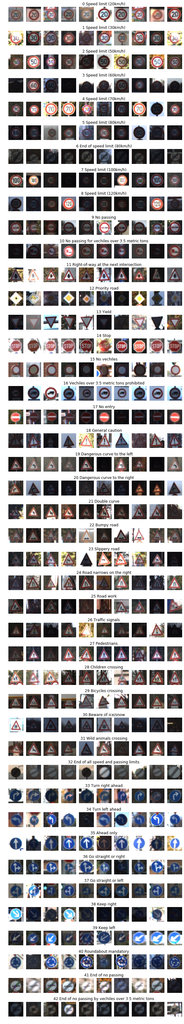

```python
### Data exploration visualization code goes here.
import matplotlib.pyplot as plt
from random import randint
# Visualizations will be shown in the notebook.
%matplotlib inline

# print("Image dimensions: ", X_train[0].shape)

cols = 10
f, ax = plt.subplots(n_classes, cols, figsize=(10, 60))
class_elements = []
for i in range(n_classes):
    x_current_class = X_train[y_train == i]
    random_indexes = [randint(0, len(x_current_class)-1) for p in range(0, cols)]
    for j in range(cols):
        ax[i][j].imshow( x_current_class[random_indexes[j]] )
        ax[i][j].axis('off')
        if j == cols // 2:
            temp_title = "%d %s" % (i, class_labels['SignName'][i])
            ax[i][j].set_title(temp_title)
    class_elements.append(len(x_current_class))
```

## Step 2: Design and Test a Model Architecture

### Model Architecture

```python
### Define your architecture here.
### Feel free to use as many code cells as needed.
from sklearn.utils import shuffle
import tensorflow as tf
from tensorflow.contrib.layers import flatten


def LeNet(x, keep_prob):
    """
    Creates LeNet CNN architecture.
    """
    mu = 0
    sigma = 0.1
    img_depth = int(x.shape[3])

    weights = {
        'wc1': tf.Variable(tf.random_normal(shape=[5, 5, img_depth, 60], mean = mu, stddev = sigma)),   # (height, width, input_depth, output_depth)
        'wc2': tf.Variable(tf.random_normal(shape=[5, 5, 60, 60], mean = mu, stddev = sigma )),         # (height, width, input_depth, output_depth)
        'wf1': tf.Variable(tf.random_normal(shape=[1500, 120], mean = mu, stddev = sigma)),
        'wf2': tf.Variable(tf.random_normal(shape=[120, 84], mean = mu, stddev = sigma)),
        'out': tf.Variable(tf.random_normal(shape=[84, n_classes], mean = mu, stddev = sigma)),
    }
    biases = {
        'bc1': tf.Variable(tf.zeros([60])),
        'bc2': tf.Variable(tf.zeros([60])),
        'bf1': tf.Variable(tf.zeros([120])),
        'bf2': tf.Variable(tf.zeros([84])),
        'out': tf.Variable(tf.zeros([n_classes]))
    }

    # Layer 1: Convolutional. Input = 32x32x1. Output = 28x28x60.
    conv_layer1 = tf.nn.conv2d(x, weights['wc1'], strides=[1, 1, 1, 1], padding='VALID')
    conv_layer1 = tf.add(conv_layer1, biases['bc1'])
    # Activation.
    conv_layer1 = tf.nn.relu(conv_layer1)
    # Pooling. Input = 28x28x6. Output = 14x14x6.
    conv_layer1 = tf.nn.max_pool(conv_layer1, ksize=[1, 2, 2, 1], strides=[1, 2, 2, 1], padding='VALID')

    # Layer 2: Convolutional. Input = 14x14x6. Output = 10x10x16.
    conv_layer2 = tf.nn.conv2d(conv_layer1, weights['wc2'], strides=[1, 1, 1, 1], padding='VALID')
    conv_layer2 = tf.add(conv_layer2, biases['bc2'])
    # Activation.
    conv_layer2 = tf.nn.relu(conv_layer2)

    # Pooling. Input = 10x10x16. Output = 5x5x16.
    conv_layer2 = tf.nn.max_pool(conv_layer2, ksize=[1, 2, 2, 1], strides=[1, 2, 2, 1], padding='VALID')

    # Flatten. Input = 5x5x16. Output = 400.
    fc0 = flatten(conv_layer2)
    fc0 = tf.nn.dropout(fc0, keep_prob)

    # Layer 3: Fully Connected. Input = 400. Output = 120.
    fc1 = tf.matmul(fc0, weights['wf1']) + biases['bf1']
    # Activation.
    fc1 = tf.nn.relu(fc1)
    fc1 = tf.nn.dropout(fc1, keep_prob)

    # Layer 4: Fully Connected. Input = 120. Output = 84.
    fc2 = tf.matmul(fc1, weights['wf2']) + biases['bf2']

    # Activation.
    fc2 = tf.nn.relu(fc2)
    fc2 = tf.nn.dropout(fc2, keep_prob)

    # Layer 5: Fully Connected. Input = 84. Output = n_class.
    logits = tf.matmul(fc2, weights['out']) + biases['out']
    return logits

# x = tf.placeholder(tf.float32, (None, 32, 32, 3))
# logits = LeNet(x, 0.7)
```

```python
x = tf.placeholder(tf.float32, (None, 32, 32, 1))
y = tf.placeholder(tf.int32, (None))
keep_prob = tf.placeholder_with_default(1.0, shape=())

one_hot_y = tf.one_hot(y, n_classes)
```

### Train, Validate and Test the Model

A validation set can be used to assess how well the model is performing. A low accuracy on the training and validation sets imply underfitting. A high accuracy on the training set but low accuracy on the validation set implies overfitting.

```
(-0.5, 31.5, 31.5, -0.5)
```

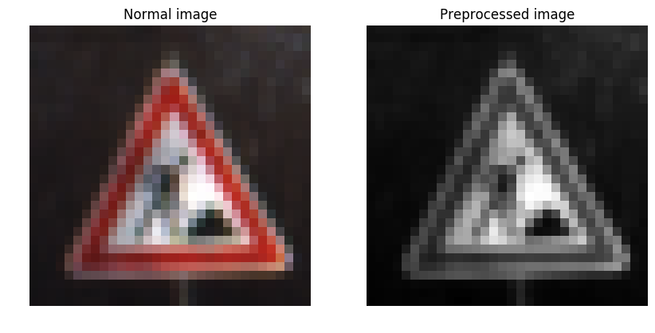

[figure not shown]

```python
### Train your model here.
### Calculate and report the accuracy on the training and validation set.
### Once a final model architecture is selected,
### the accuracy on the test set should be calculated and reported as well.
### Feel free to use as many code cells as needed.


def sharpen(image):
    """
    Returns a modified the images with a random sharpening between the given alpha
    and lightness
    """
    sharp = iaa.Sharpen(alpha=(0.0, 1.0), lightness=(0.75, 2.0))
    image = sharp.augment_image(image)
    return image

def zoom(image):
    """
    Returns a zoomed images within a given zooming range.
    """
    zoom = iaa.Affine(scale = (1, 1.3))   # zoom min, max
    image = zoom.augment_image(image)
    return image

def pan(image):
    """
    Returns an image, which has a random pan.
    """
    pan = iaa.Affine(translate_percent={ "x": (-0.1, 0.1), "y": (-0.1, 0.1)})    # +-10% translation for x, y axis
    image = pan.augment_image(image)
    return image

def img_random_brigthness(image):
    """
    Returns an image, which brightness changed randomly.
    """
    brightness = iaa.Multiply( (0.2, 1.2) )    # multiplies the pixel intensities with a random number between the limits.
    image = brightness.augment_image(image)
    return image

def random_augment(image):
    """
    Returns a randomly augmented image.
    """
    if np.random.rand() < 0.5:   # 50% percent is true
        image = pan(image)
    if np.random.rand() < 0.5:   # 50% percent is true
        image = zoom(image)
    if np.random.rand() < 0.5:   # 50% percent is true
        image = img_random_brigthness(image)
    if np.random.rand() < 0.5:   # 50% percent is true
        image = sharpen(image)
    return image

def batch_aug_gen_proc(X_train, y_train,  batch_size):
    """
    Generates augmented images with a given batch size, and attach to the current
    image list
    """
    new_X_train = np.zeros((X_train.shape[0] + batch_size, X_train.shape[1], X_train.shape[2], X_train.shape[3]), dtype=np.uint8)
    new_y_train = np.zeros((y_train.shape[0] + batch_size))

    new_X_train[:X_train.shape[0]] = X_train
    new_y_train[:y_train.shape[0]] = y_train

    for i in range(batch_size):
        random_index = randint(0, X_train.shape[0]-1)
        new_X_train[X_train.shape[0] + i] = random_augment(X_train[random_index])
        new_y_train[X_train.shape[0] + i] = y_train[random_index]

    return new_X_train, new_y_train

def alpha_beta_auto_correction(img):
    """
    Extends the range of the image pixel intensity range to [0 255]
    """
    inputRange = np.amax(img) - np.amin(img)
    wantedrange = 255.0
    alpha = wantedrange / inputRange
    beta = - alpha * np.amin(img)
    return (img * alpha + beta).astype("uint8")

def preprocess_multiple_images(image_list):
    """
    Preprocess multiple images, and return the processed image list.
    """
    output = np.zeros((image_list.shape[0], image_list.shape[1], image_list.shape[2], 1))

    for i in range(len(image_list)):
        image = image_list[i]
        image = cv2.cvtColor(image, cv2.COLOR_RGB2GRAY)
        image = alpha_beta_auto_correction(image)

        # image is not normalized
        if np.max(image) > 1 :
            image = image / 255
        try:
            output[i] = image.reshape((image_list.shape[1], image_list.shape[2]), image.shape[3])
        except:
            output[i] = image.reshape(32, 32, 1) # (image_list.shape[1], image_list.shape[2]), 1)
    return output

def preprocess_single_images(input_image):
    """
    Preprocess a single image.
    """
    image = np.copy(input_image)
    image = cv2.resize(image, (32, 32))
    image = cv2.cvtColor(image, cv2.COLOR_RGB2GRAY)
    image = alpha_beta_auto_correction(image)

    # image is not normalized
    if np.max(image) > 1 :
        image = image / 255
    try:
        output = image.reshape((image_list.shape[1], image_list.shape[2]), image.shape[3])
    except:
        output = image.reshape(32, 32, 1)
    return output

index = randint(0, X_train.shape[0]-1)
f, ax = plt.subplots(1, 2, figsize=(10, 10))
ax[0].imshow(X_train[index])
ax[0].set_title("Normal image")
ax[0].axis('off')
img = preprocess_single_images(X_train[index])
ax[1].imshow(img[:,:,0], cmap = 'gray')
ax[1].set_title("Preprocessed image")
ax[1].axis('off')

index = randint(0, X_train.shape[0]-1)
f, ax = plt.subplots(1, 2, figsize=(10, 10))
ax[0].imshow(X_train[index])
ax[0].set_title("Normal image")
ax[0].axis('off')
img = random_augment(X_train[index])
ax[1].imshow(img[:,:,0], cmap = 'gray')
ax[1].set_title("Augmented image")
ax[1].axis('off')
```

```python
# rate = 0.0005
rate = 0.0005
EPOCHS = 15
BATCH_SIZE = 128

logits = LeNet(x, keep_prob)
cross_entropy = tf.nn.softmax_cross_entropy_with_logits(labels=one_hot_y, logits=logits)
loss_operation = tf.reduce_mean(cross_entropy)
optimizer = tf.train.AdamOptimizer(learning_rate = rate)
training_operation = optimizer.minimize(loss_operation)

# X_train, y_train = shuffle(X_train, y_train)

# reset X_train values
X_train, y_train = train['features'], train['labels']
X_valid, y_valid = valid['features'], valid['labels']

X_train, y_train = shuffle(X_train, y_train)
# X_train, y_train = batch_aug_gen_proc(X_train, y_train, 10000)
# X_train = preprocess_multiple_images(X_train)
X_valid = preprocess_multiple_images(X_valid)
```

```python
correct_prediction = tf.equal(tf.argmax(logits, 1), tf.argmax(one_hot_y, 1))
accuracy_operation = tf.reduce_mean(tf.cast(correct_prediction, tf.float32))
saver = tf.train.Saver()

def evaluate(X_data, y_data):
    """
    Evaluates the given X_data input with y_data labels
    Returns the average accuracy.
    """
    num_examples = len(X_data)
    total_accuracy = 0
    sess = tf.get_default_session()
    for offset in range(0, num_examples, BATCH_SIZE):
        batch_x, batch_y = X_data[offset:offset+BATCH_SIZE], y_data[offset:offset+BATCH_SIZE]
        accuracy = sess.run(accuracy_operation, feed_dict={x: batch_x, y: batch_y})
        total_accuracy += (accuracy * len(batch_x))
    return total_accuracy / num_examples
```

```python
overal_train_acc = []
overal_valid_acc = []
with tf.Session() as sess:
    sess.run(tf.global_variables_initializer())
    num_examples = len(X_train)

    print("Training...")
    print()
    for i in range(EPOCHS):
        X_train, y_train = shuffle(X_train, y_train)
        for offset in range(0, num_examples, BATCH_SIZE):
            end = offset + BATCH_SIZE
            batch_x, batch_y = batch_aug_gen_proc(X_train[offset:end], y_train[offset:end], np.uint16 ( BATCH_SIZE / 5))
            batch_x = preprocess_multiple_images(batch_x)
#             batch_x, batch_y = X_train[offset:end], y_train[offset:end]
            sess.run(training_operation, feed_dict={x: batch_x, y: batch_y, keep_prob: 0.5})

        training_accuracy = evaluate(batch_x, batch_y)
        print("EPOCH {} ...".format(i+1), end = "\t")
        print("Training Accuracy = {:.3f}".format(training_accuracy), end = "\t")

        validation_accuracy = evaluate(X_valid, y_valid)
#         print("EPOCH {} ...".format(i+1))
        print("Validation Accuracy = {:.3f}".format(validation_accuracy))
#         print()
        overal_train_acc.append(training_accuracy)
        overal_valid_acc.append(validation_accuracy)

    saver.save(sess, './lenet')
    print("Model saved")
```

```
Training...

EPOCH 1 ...	Training Accuracy = 0.294	Validation Accuracy = 0.320
EPOCH 2 ...	Training Accuracy = 0.588	Validation Accuracy = 0.529
EPOCH 3 ...	Training Accuracy = 0.706	Validation Accuracy = 0.719
EPOCH 4 ...	Training Accuracy = 0.816	Validation Accuracy = 0.802
EPOCH 5 ...	Training Accuracy = 0.897	Validation Accuracy = 0.853
EPOCH 6 ...	Training Accuracy = 0.919	Validation Accuracy = 0.895
EPOCH 7 ...	Training Accuracy = 0.912	Validation Accuracy = 0.904
EPOCH 8 ...	Training Accuracy = 0.949	Validation Accuracy = 0.933
EPOCH 9 ...	Training Accuracy = 0.926	Validation Accuracy = 0.938
EPOCH 10 ...	Training Accuracy = 0.971	Validation Accuracy = 0.946
EPOCH 11 ...	Training Accuracy = 0.941	Validation Accuracy = 0.956
EPOCH 12 ...	Training Accuracy = 0.963	Validation Accuracy = 0.958
EPOCH 13 ...	Training Accuracy = 0.978	Validation Accuracy = 0.960
EPOCH 14 ...	Training Accuracy = 0.985	Validation Accuracy = 0.968
EPOCH 15 ...	Training Accuracy = 0.985	Validation Accuracy = 0.970
Model saved
```

## Step 3: Test a Model on New Images

```python
X_test, y_test = test['features'], test['labels']

X_test = preprocess_multiple_images(X_test)
with tf.Session() as sess:
    saver.restore(sess, tf.train.latest_checkpoint('.'))

    test_accuracy = evaluate(X_test, y_test)
    print("Test Accuracy = {:.3f}".format(test_accuracy))
```

```
Test Accuracy = 0.956
```

```python
X_train, y_train = train['features'], train['labels']
X_train = preprocess_multiple_images(X_train)
# X_test = preprocess_multiple_images(X_test)
with tf.Session() as sess:
    saver.restore(sess, tf.train.latest_checkpoint('.'))

    test_accuracy = evaluate(X_train, y_train)
    print("Test Accuracy = {:.3f}".format(test_accuracy))
```

[output not shown]

[figure not shown]

```python
# saveOveral_acc = np.array(overal_acc)
# saveOveral_acc = saveOveral_acc.reshape(EPOCHS, -1)
plt.plot(overal_train_acc, label="Traning accuracy")
plt.plot(overal_valid_acc, label="Traning accuracy")
plt.title("Training and vaildation accuracy during the training")
plt.xlabel("EPOCHS")
plt.ylabel("Accuracy")
plt.legend()
```

```python
def LeNet_predict(X_input):
    """
    Creates a single prediction with the trained classifier for the given image.
    """
    with tf.Session() as sess:
        sess.run(tf.global_variables_initializer())
        saver.restore(sess, tf.train.latest_checkpoint('.'))
        batch_x = [preprocess_single_images(X_input)]
        logits__ = sess.run(logits, feed_dict={x: batch_x})
    return np.argmax(logits__, axis=1)

def get_sign_name_string(input_class_id):
    tempStr = str(class_labels['SignName'][input_class_id[0]])
    return tempStr

tf.logging.set_verbosity(tf.logging.ERROR)

def softmax(x):
    """Compute softmax values for each sets of scores in x."""
    return np.exp(x) / np.sum(np.exp(x))



# i = 0
# r = requests.get(url[i], stream=True)
# temp_img = Image.open(r.raw)
# probab = LeNet_predict_max_n_probability(temp_img, 4)

# for i in range(len(url)):
#     r = requests.get(url[i], stream=True)
#     temp_img = Image.open(r.raw)
#     results = LeNet_predict_max_n_probability(temp_img)
#     print("Image", i, " results:\n", results)
```

### Load and Output the Images and predict the Sign Type for Each Image

[output not shown]

[output cut: 16 more lines]

[output not shown]

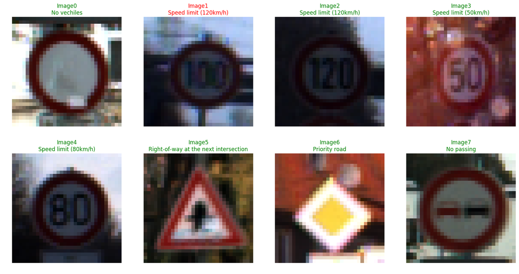

```python
### Load the images and plot them here.
### Feel free to use as many code cells as needed.
cols = 4
rows = 2

random_indexes = [randint(0, len(X_test)-1) for p in range(0, cols * rows)]

X_test, y_test = test['features'], test['labels']
X_disp_test = X_test[random_indexes]
y_disp_test = y_test[random_indexes]

# X_train, y_train = train['features'], train['labels']
# X_disp_test = X_train[random_indexes]
# y_disp_test = y_train[random_indexes]

def LeNet_predict_max_n_probability(X_input, n=5):
    """
    Creates a prediction for a single image, and returns the biggest n guesses.
    """
    with tf.Session() as sess:
        sess.run(tf.global_variables_initializer())
        saver.restore(sess, tf.train.latest_checkpoint('.'))
        batch_x = [preprocess_single_images(X_input)]
        logits__ = sess.run(logits, feed_dict={x: batch_x})
        probabs = softmax(logits__)

        # source: https://stackoverflow.com/questions/6910641/how-do-i-get-indices-of-n-maximum-values-in-a-numpy-array
        idx = (-probabs).argsort()[0][:n]
    return np.array( [idx, probabs[0][idx]] )

def print_table(idx, results, y_disp_test):
    """
    Generates a markdown table text for the results.
    """
    print( "Image" + str(idx) + " (\"" + get_sign_name_string([y_disp_test]) + "\") results:")
    print("| Class Id 			   | Probability    			     | &nbsp; &nbsp; &nbsp; &nbsp; &nbsp; &nbsp;&nbsp; &nbsp; &nbsp;&nbsp; &nbsp; &nbsp;&nbsp; &nbsp; &nbsp;&nbsp; &nbsp; &nbsp;Prediction&nbsp; &nbsp; &nbsp; &nbsp; &nbsp;&nbsp; &nbsp; &nbsp; &nbsp; &nbsp;&nbsp; &nbsp; &nbsp; &nbsp; &nbsp;&nbsp; &nbsp; &nbsp; &nbsp; &nbsp;	               |")
    print("|:---------------------:|:-------------------------------:|:-------------------------------:|")

    for i in range(len(results[0])):
        print( "| {}\t| {:2.5f} | {}\t|".format( int(results[0][i]), results[1][i], get_sign_name_string([int(results[0][i])]) ))
    print()

f, ax = plt.subplots(rows, cols, figsize=(20, 10))
for i in range(rows):
    for j in range(cols):
        idx = i * cols + j
        temp_img = X_disp_test[idx]
        predicted_label = LeNet_predict(temp_img)
        ax[i][j].imshow(alpha_beta_auto_correction(temp_img))

        color = 'red'
        if y_disp_test[idx] == predicted_label:
            color = 'green'
        title = "Image" + str(idx) + "\n" + class_labels['SignName'][predicted_label[0]]
        ax[i][j].set_title(title, color=color)
        ax[i][j].axis('off')

        results = LeNet_predict_max_n_probability(temp_img)
        print_table(idx, results, y_disp_test[idx])
#         print_table("Image", idx, " results:\n", results)

# plt.imshow( alpha_beta_auto_correction(X_disp_test[0]))
# print(class_labels['SignName'][predicted_label[0]])
```

### Analyze Performance

```
Accuracy: 83.333 %
```

[figure not shown]

```python
### Calculate the accuracy for these 5 new images.
### For example, if the model predicted 1 out of 5 signs correctly, it's 20% accurate on these new images.
import requests
from PIL import Image
url = [
        'https://previews.123rf.com/images/pejo/pejo0907/pejo090700003/5155701-german-traffic-sign-no-205-give-way.jpg',
        'https://sheelabhadra.github.io/images/Traffic-sign-recognition/road_work.jpg',
        'https://anks4.github.io/Traffic-Sign-Classifier/images/img6.jpg',
        'https://media.istockphoto.com/vectors/turn-right-ahead-german-road-sign-blue-vector-id467030179?k=6&m=467030179&s=612x612&w=0&h=1JW9bnaEXh6IgZ-IE2bhqq3-r4aeprCFnshBwcYxRj8=',
        'https://cdn.xl.thumbs.canstockphoto.com/road-sign-turn-left-against-the-blue-sky-stock-photography_csp36280602.jpg',
        'https://cdn-images-1.medium.com/max/1600/1*nhvFD7uT718W59UlRYaIWQ.jpeg'
      ]
labels = [13, 25, 4, 33, 34, 14] # this is added manually based on the pictures

f, ax = plt.subplots(1, len(url), figsize = (20, 10))

correct_predictions = 0
for i in range(len(url)):
    r = requests.get(url[i], stream=True)
    temp_img = Image.open(r.raw)
    ax[i].imshow(temp_img, cmap=plt.get_cmap('gray'))
    predicted_label = LeNet_predict(temp_img)

    color = 'red'
    if labels[i] == predicted_label:
        color = 'green'
        correct_predictions += 1
    title = "Image" + str(i) + "\n" + get_sign_name_string(predicted_label)
    ax[i].set_title(title, color=color)
#     print(predicted_label)
    ax[i].axis('off')
accuracy = correct_predictions / len(url) * 100

print( "Accuracy: {:2.3f} %".format(accuracy) )

# plt.title(get_sign_name_string(predicted_label))
```

### Output Top 5 Softmax Probabilities For Each Image Found on the Web

```python
### Print out the top five softmax probabilities for the predictions on the German traffic sign images found on the web.
### Feel free to use as many code cells as needed.

    for i in range(len(url)):
        r = requests.get(url[i], stream=True)
        temp_img = Image.open(r.raw)

        results = LeNet_predict_max_n_probability(temp_img)
        print_table(i, results, labels[i])
```

[output not shown]